# 推文波峰报告

Kang

2022-12-17

原数据中，每天的推文强度跟90%、85%、80%、75%分位推文强度高值的比较如下图。有些波峰特别高，为了方便查看，对纵轴取了对数。反正这个图没什么动用就是了，看看就好了。

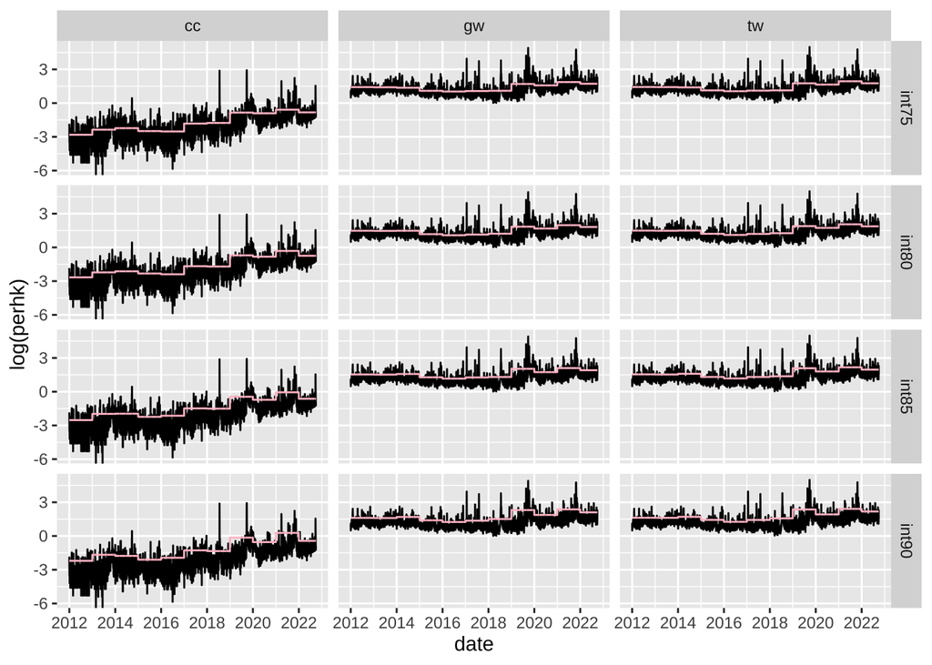

再计算这些口径下，不同分位数情况下，高值日期推文数的条数，和占总各口径总推文数比例。条数为：

| int_idx | cc | gw | tw |
| --- | --- | --- | --- |
| int75 | 255921 | 3230100 | 3368526 |
| int80 | 232485 | 2873715 | 2990425 |
| int85 | 204904 | 2475893 | 2570806 |
| int90 | 169731 | 2020037 | 2094429 |

比例为：

| int_idx | cc | gw | tw |
| --- | --- | --- | --- |
| int75 | 0.5835977 | 0.4804194 | 0.4789100 |
| int80 | 0.5301546 | 0.4274135 | 0.4251546 |
| int85 | 0.4672594 | 0.3682447 | 0.3654966 |
| int90 | 0.3870515 | 0.3004443 | 0.2977691 |

```
##
##       3  4  5  6  7  8  9 10 11 13 14 15
##   cc 12  8  4  5  0  2  2  0  1  1  0  0
##   gw 14  7  9  3  2  2  1  1  1  1  1  0
##   tw 12  7  9  2  3  2  2  0  1  1  0  1
```

通过可视化，可以看出CC和GW及TW的表现有所不同。

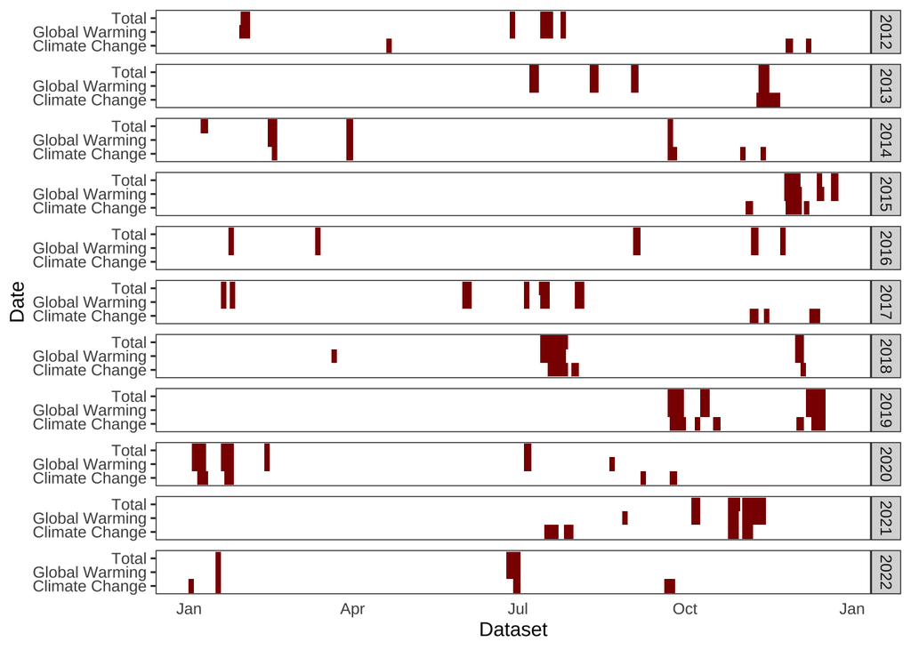